# Practical Machine Learning Report_Course Project

### **Exploring Correlation**

Here I go on with the correlation analysis between the variables before the model construction.

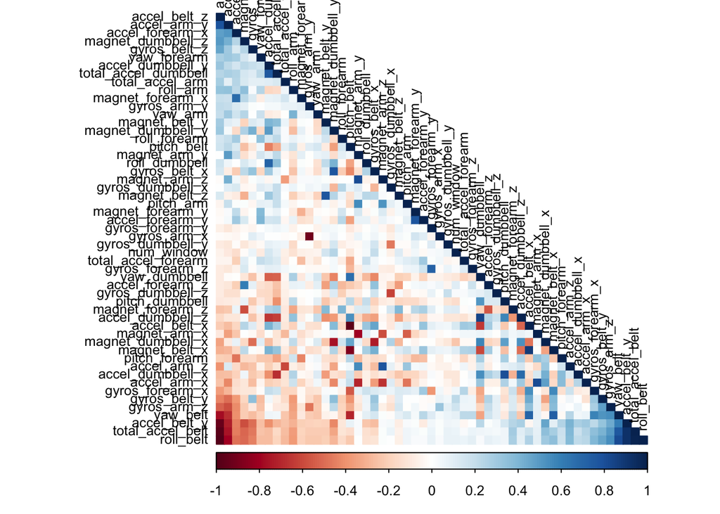

```r
# Apply the correlation analysis for the dataset
library(corrplot)
library(lattice)
library(ggplot2)
library(rpart.plot)

correlation <- cor(train_subset[,-54])
corrplot(correlation, order = "FPC", method = "color", type = "lower",
         tl.cex = 0.8, tl.col = rgb(0, 0, 0))
```

In the upper correlation analysis, all the involved variables are shown in the correlation plot. The blue colour represents the positive correlation efficients, while the red colour represents the negative efficients.

### **Prediction Model Construction**

In this section, I apply three different approaches (Decision Tree Model, Generalized Boosted Model and Random Forest Model) for the modelling process on the training dataset. The one with higehr accuracy efficient will be used for the quiz section in the end of the project.

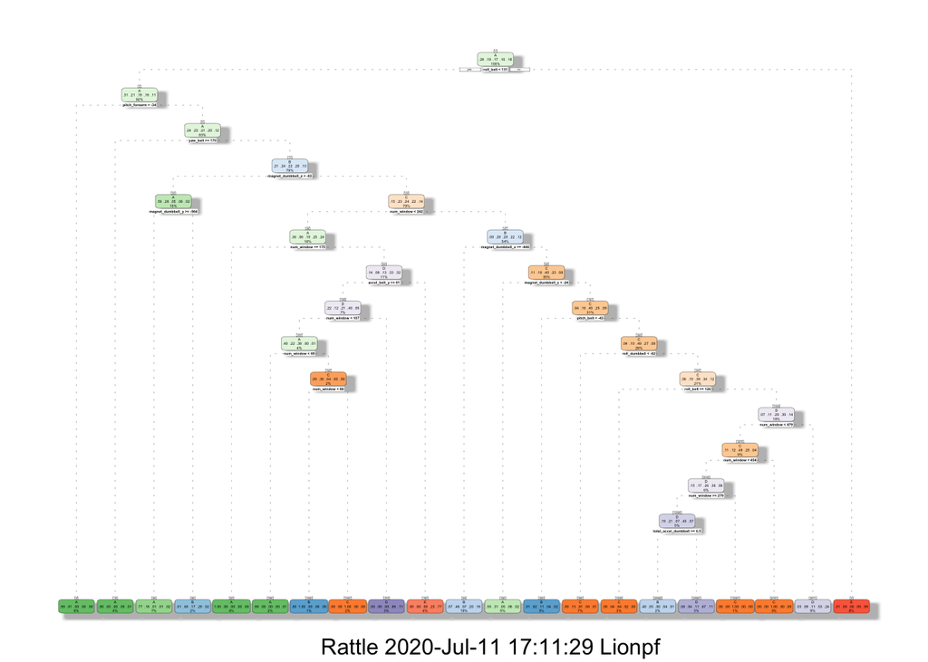

```r
# Plot the decision tree
set.seed(1000)
decision_tree <- rpart(classe~.,data=train_subset,method="class")
fancyRpartPlot(decision_tree)
```

```r
# Predictions from the decision tree model
prediction_decision_tree <- predict(decision_tree,newdata = test_subset,
                                    type = "class")
conf_decision_tree <- confusionMatrix(prediction_decision_tree,as.factor(test_subset$classe))
conf_decision_tree
```

```
## Confusion Matrix and Statistics
##
##           Reference
## Prediction    A    B    C    D    E
##          A 1262  144   26   52   14
##          B  102  721   99  225  156
##          C    0   42  659   23    1
##          D   26   41   71  456  157
##          E    5    1    0   48  573
##
## Overall Statistics
##
##                Accuracy : 0.7486
##                  95% CI : (0.7362, 0.7607)
##     No Information Rate : 0.2845
##     P-Value [Acc > NIR] : < 2.2e-16
##
##                   Kappa : 0.6807
##
##  Mcnemar's Test P-Value : < 2.2e-16
##
## Statistics by Class:
##
##                      Class: A Class: B Class: C Class: D Class: E
## Sensitivity            0.9047   0.7597   0.7708  0.56716   0.6360
## Specificity            0.9327   0.8528   0.9837  0.92805   0.9865
## Pos Pred Value         0.8425   0.5533   0.9090  0.60719   0.9139
## Neg Pred Value         0.9610   0.9367   0.9531  0.91621   0.9233
## Prevalence             0.2845   0.1935   0.1743  0.16395   0.1837
## Detection Rate         0.2573   0.1470   0.1344  0.09299   0.1168
## Detection Prevalence   0.3055   0.2657   0.1478  0.15314   0.1279
## Balanced Accuracy      0.9187   0.8063   0.8772  0.74761   0.8112
```

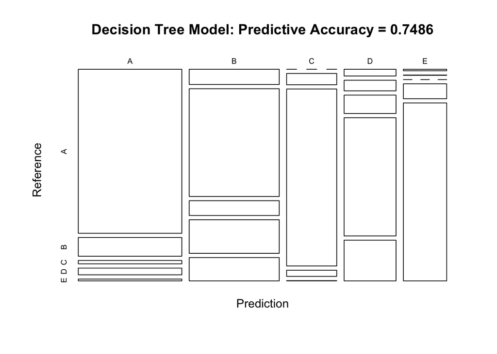

```r
plot(conf_decision_tree$table, col = conf_decision_tree$byClass,
     main = paste("Decision Tree Model: Predictive Accuracy =",
                  round(conf_decision_tree$overall['Accuracy'], 4)))
```

Then the generalized boost model is as follows.

```r
# Generalized Boosted Model
set.seed(1000)
control_GBM <- trainControl(method = "repeatedcv", number = 5, repeats = 1)
fit_GBM  <- train(classe ~ ., data = train_subset, method = "gbm",
                  trControl = control_GBM, verbose = FALSE)
fit_GBM$finalModel
```

```
## A gradient boosted model with multinomial loss function.
## 150 iterations were performed.
## There were 53 predictors of which 53 had non-zero influence.
```

```r
predict_GBM <- predict(fit_GBM, newdata=test_subset)
conf_GBM <- confusionMatrix(predict_GBM, as.factor(test_subset$classe))
conf_GBM
```

```
## Confusion Matrix and Statistics
##
##           Reference
## Prediction    A    B    C    D    E
##          A 1392    6    0    0    0
##          B    3  936    6    3    2
##          C    0    7  848   16    0
##          D    0    0    1  784    8
##          E    0    0    0    1  891
##
## Overall Statistics
##
##                Accuracy : 0.9892
##                  95% CI : (0.9859, 0.9919)
##     No Information Rate : 0.2845
##     P-Value [Acc > NIR] : < 2.2e-16
##
##                   Kappa : 0.9863
##
##  Mcnemar's Test P-Value : NA
##
## Statistics by Class:
##
##                      Class: A Class: B Class: C Class: D Class: E
## Sensitivity            0.9978   0.9863   0.9918   0.9751   0.9889
## Specificity            0.9983   0.9965   0.9943   0.9978   0.9998
## Pos Pred Value         0.9957   0.9853   0.9736   0.9887   0.9989
## Neg Pred Value         0.9991   0.9967   0.9983   0.9951   0.9975
## Prevalence             0.2845   0.1935   0.1743   0.1639   0.1837
## Detection Rate         0.2838   0.1909   0.1729   0.1599   0.1817
## Detection Prevalence   0.2851   0.1937   0.1776   0.1617   0.1819
## Balanced Accuracy      0.9981   0.9914   0.9931   0.9865   0.9943
```

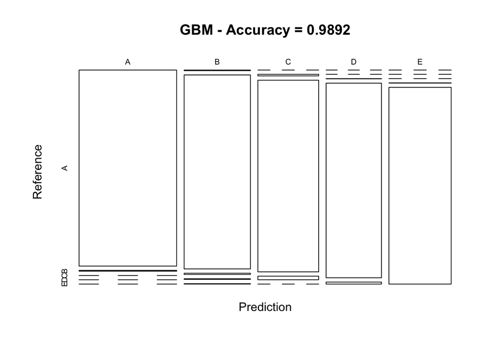

```r
plot(conf_GBM$table, col = conf_GBM$byClass,
     main = paste("GBM - Accuracy =", round(conf_GBM$overall['Accuracy'], 4)))
```

The random forest model comes in the following section.

```r
# Random forest model
set.seed(1000)
control_RFM <- trainControl(method = "repeatedcv", number = 5, repeats = 2)
fit_RFM  <- train(classe ~ ., data = train_subset, method = "rf",
                 trControl = control_RFM, verbose = FALSE)
fit_RFM$finalModel
```

```
##
## Call:
##  randomForest(x = x, y = y, mtry = param$mtry, verbose = FALSE)
##                Type of random forest: classification
##                      Number of trees: 500
## No. of variables tried at each split: 27
##
##         OOB estimate of  error rate: 0.21%
## Confusion matrix:
##      A    B    C    D    E class.error
## A 4185    0    0    0    0 0.000000000
## B    7 2838    3    0    0 0.003511236
## C    0    5 2562    0    0 0.001947799
## D    0    0    8 2403    1 0.003731343
## E    0    1    0    6 2699 0.002586844
```

```r
predict_RFM <- predict(fit_RFM, newdata = test_subset)
conf_RFM <- confusionMatrix(predict_RFM, as.factor(test_subset$classe))
conf_RFM
```

```
## Confusion Matrix and Statistics
##
##           Reference
## Prediction    A    B    C    D    E
##          A 1394    4    0    0    0
##          B    0  942    1    0    0
##          C    0    3  854    4    0
##          D    0    0    0  800    1
##          E    1    0    0    0  900
##
## Overall Statistics
##
##                Accuracy : 0.9971
##                  95% CI : (0.9952, 0.9984)
##     No Information Rate : 0.2845
##     P-Value [Acc > NIR] : < 2.2e-16
##
##                   Kappa : 0.9964
##
##  Mcnemar's Test P-Value : NA
##
## Statistics by Class:
##
##                      Class: A Class: B Class: C Class: D Class: E
## Sensitivity            0.9993   0.9926   0.9988   0.9950   0.9989
## Specificity            0.9989   0.9997   0.9983   0.9998   0.9998
## Pos Pred Value         0.9971   0.9989   0.9919   0.9988   0.9989
## Neg Pred Value         0.9997   0.9982   0.9998   0.9990   0.9998
## Prevalence             0.2845   0.1935   0.1743   0.1639   0.1837
## Detection Rate         0.2843   0.1921   0.1741   0.1631   0.1835
## Detection Prevalence   0.2851   0.1923   0.1756   0.1633   0.1837
## Balanced Accuracy      0.9991   0.9962   0.9986   0.9974   0.9993
```

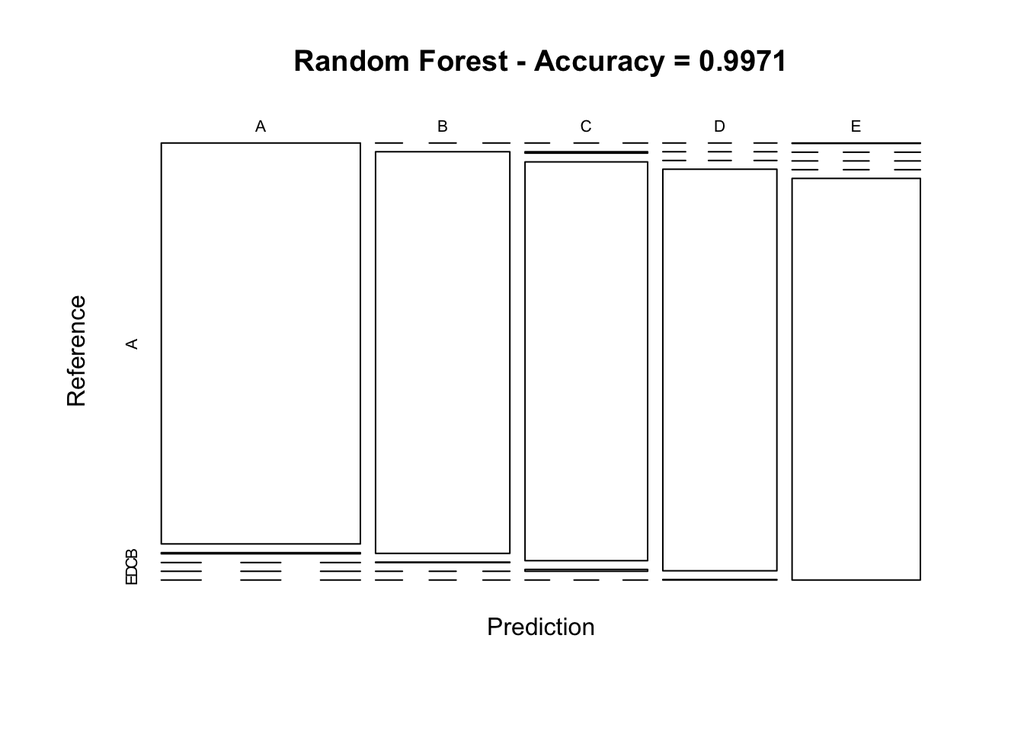

```r
plot(conf_RFM$table, col = conf_RFM$byClass,
     main = paste("Random Forest - Accuracy =",
                  round(conf_RFM$overall['Accuracy'], 4)))
```

### **Apply the selected data on the test.data**

The upper analysis indicates the accuracy of three different model.

Here the random forest model is selected to be the model for test data.

```r
predict_test <- predict(fit_RFM, newdata=test_data)
predict_test
```

```
##  [1] B A B A A E D B A A B C B A E E A B B B
## Levels: A B C D E
```